# Friedman’s ANOVA

Disclaimer: Het peer review proces voor deze toets is nog niet afgerond; daarom is deze pagina nog in concept.

# 1 Toepassing

Gebruik *Friedman’s ANOVA* om de gemiddelde rangnummers[^1] te vergelijken voor de verdelingen van drie of meer herhaalde metingen van één groep of voor de verdelingen van drie of meer gepaarde groepen.[^2]<sup>,</sup>[^3] *Friedman’s ANOVA* is een alternatief voor de repeated measures ANOVA wanneer de data niet aan de assumptie van normaliteit voldoet. Daarnaast hebben uitbijters minder invloed op het resultaat van *Friedman’s ANOVA* in vergelijking tot de repeated measures ANOVA. Echter, als de data aan de assumpties van de repeated measures ANOVA voldoet, heeft die toets een hoger onderscheidend vermogen dan *Friedman’s ANOVA*.[^4]

# 2 Onderwijscasus

Uit de Nationale Studenten Enquête (NSE) blijkt dat studenten ontevreden zijn over het horeca-aanbod op de campus van hun hogeschool. De vastgoedmanager van de Facultaire Dienst (FD) van deze hogeschool is nieuwsgierig hoe de verschillende eetgelegenheden op de campus gewaardeerd worden door studenten om zo te inventarisen op welke manier het horeca-aanbod verbeterd kan worden. Als vervolgonderzoek op de NSE wordt een groep studenten gevraagd om de eetgelegenheden op de campus te beoordelen (met een cijfer tussen 1 en 10). Aan de hand daarvan vergelijkt de vastgoedmanager eetgelegenheden in vier gebouwen: het hoofdgebouw, het bestuursgebouw, het sportcentrum en het cultuurcentrum Rembrandt. Met deze gegevens wil de vastgoedmanager onderzoeken of er verschillen zijn in de waarderingscijfers van de eetgelegenheden in de vier gebouwen. Als deze verschillen aanwezig zijn, is zij benieuwd welke eetgelegenheden van elkaar verschillen.

Dit onderzoek vertaalt zich in de volgende combinatie van hypothesen, waarbij de nulhypothese zo geformuleerd is dat er geen effect of verschil is en de alternatieve hypothese zo geformuleerd is dat er wel een effect of verschil is.

*H<sub>0</sub>*: Het gemiddelde rangnummer van de verdelingen van de beoordelingen van studenten is hetzelfde voor de eetgelegenheid in het hoofdgebouw, het bestuursgebouw, het sportcentrum en het cultuurcentrum Rembrandt.

*H<sub>A</sub>*: Het gemiddelde rangnummer van de verdelingen van de beoordelingen van studenten is niet hetzelfde voor de eetgelegenheid in het hoofdgebouw, het bestuursgebouw, het sportcentrum en het cultuurcentrum Rembrandt.

# 3 Assumpties

Om een valide toetsresultaat te bereiken, moeten de data aan een aantal assumpties voldoen. Het meetniveau van de afhankelijke variabele is ordinaal[^5] of continu.[^6] In deze toetspagina staat een casus met continue data centraal; een casus met ordinale data met bijbehorende uitwerking is te vinden in deze toetspagina. Bij herhaalde metingen van dezelfde observatie-eenheden, moet de groep observatie-eenheden drie of meer keren gemeten zijn en een willekeurige steekproef van de populatie zijn. Bij gepaarde groepen, moet elk paar bestaan uit drie of meer gepaarde observatie-eenheden en moet de steekproef met alle paren een willekeurige steekproef van de populatie zijn.[^7]

# 4 Effectmaat

De p-waarde geeft aan of het verschil tussen groepen significant is. De grootte van het verschil of effect is echter ook relevant. Een effectmaat is een gestandaardiseerde maat die de grootte van een effect weergeeft, zodat effecten van verschillende onderzoeken met elkaar vergeleken kunnen worden.[^8] Voor *Friedman’s ANOVA* wordt de effectmaat *Kendall’s W* vaak gebruikt.[^9]<sup>,</sup>[^10]<sup>,</sup>[^11] Een indicatie om *Kendall’s W* te interpreteren is: rond 0,1 is het een klein effect, rond 0,3 is het een gemiddeld effect en rond 0,5 is het een groot effect.[^12]

# 5 Post-hoc toetsen

*Friedman’s ANOVA* toetst of er verschillen zijn tussen de verdelingen van groepen. Voer een post-hoc toets uit om te bepalen welke groepen van elkaar verschillen. Gebruik de Wilcoxon signed rank toets als post-hoc toets. De Wilcoxon signed rank toets toetst of er een verschil tussen de verdelingen is van twee gepaarde groepen (i.e. of een van beide verdelingen hogere waardes heeft dan de andere verdeling). Hoewel het minder gebruikelijk is, is de tekentoets ook een optie als post-hoc toets. Deze toets toetst het verschil tussen de medianen van twee gepaarde groepen.

Gebruik een correctie voor de p-waarden, omdat er meerdere toetsen tegelijkertijd worden gebruikt. Meerdere toetsen tegelijkertijd uitvoeren verhoogt de kans dat een van de nulhypotheses onterecht wordt verworpen en er bij toeval een verband wordt ontdekt dat er niet is (type I fout). In deze toetspagina wordt de *Bonferroni correctie* gebruikt. Deze correctie past de p-waarde aan door de p-waarde te vermenigvuldigen met het aantal uitgevoerde toetsen en verlaagt hiermee de kans op een type I fout. Een andere uitleg hiervan is dat het significantieniveau gedeeld wordt door het aantal toetsen wat leidt tot een lager significantieniveau en dus een strengere toets. Er zijn ook andere opties voor een correctie op de p-waarden.[^13]

# 6 Uitvoering

Er is een dataset `dfBeoordelingen_eetgelegenheden` ingeladen met de beoordelingen van de eetgelegenheden in het hoofdgebouw, bestuursgebouw, sportcentrum en cultuurcentrum.

## 6.1 De data bekijken

Gebruik `<dataframe>.head()` en `<dataframe>.tail()` om de structuur van de data te bekijken.

```python
import pandas as pd
## Eerste 6 observaties
print(dfBeoordelingen_eetgelegenheden.head(6))
##   Studentnummer  Eetgelegenheid  Beoordeling
## 0       4106389     Hoofdgebouw          8.0
## 1       4106389  Bestuursgebouw          5.0
## 2       4106389    Sportcentrum          8.0
## 3       4106389  Cultuurcentrum          6.0
## 4       4126054     Hoofdgebouw          8.0
## 5       4126054  Bestuursgebouw          5.0
```

```python
## Laatste 6 observaties
print(dfBeoordelingen_eetgelegenheden.tail(6))
##    Studentnummer  Eetgelegenheid  Beoordeling
## 74       4461373    Sportcentrum          9.0
## 75       4461373  Cultuurcentrum          4.0
## 76       4494467     Hoofdgebouw          7.0
## 77       4494467  Bestuursgebouw          7.0
## 78       4494467    Sportcentrum          6.0
## 79       4494467  Cultuurcentrum          8.0
```

De dataset bevat beoordelingen van studenten van eetgelegenheden in verschillende gebouwen. Gebruik `<data.frame>.<kolomnaam>.unique()` om te onderzoeken welke gebouwen er in de data aanwezig zijn.

```python
## Unieke opleidingen
print(dfBeoordelingen_eetgelegenheden['Eetgelegenheid'].unique())
```

```
## ['Hoofdgebouw' 'Bestuursgebouw' 'Sportcentrum' 'Cultuurcentrum']
```

Inspecteer om meer inzicht te krijgen in de data de groepen met `.size()` en `.quantile()`. Selecteer eerst de juiste variabelen met `dfBeoordelingen_eetgelegenheden[['Beoordeling','Eetgelegenheid']]`en groepeer daarna voor de eetgelegenheden met .groupby([‘Eetgelegenheid’]). De mediaan is gelijk aan kwantiel `0.5`.

```python
print(dfBeoordelingen_eetgelegenheden[['Beoordeling','Eetgelegenheid']].groupby(['Eetgelegenheid']).size())
```

```
## Eetgelegenheid
## Bestuursgebouw    20
## Cultuurcentrum    20
## Hoofdgebouw       20
## Sportcentrum      20
## dtype: int64
```

```python
print(dfBeoordelingen_eetgelegenheden[['Beoordeling','Eetgelegenheid']].groupby(['Eetgelegenheid']).quantile([0.25, 0.5, 0.75]))
```

```
##                      Beoordeling
## Eetgelegenheid
## Bestuursgebouw 0.25         5.00
##                0.50         5.50
##                0.75         7.00
## Cultuurcentrum 0.25         4.75
##                0.50         5.00
##                0.75         6.00
## Hoofdgebouw    0.25         6.00
##                0.50         7.00
##                0.75         8.00
## Sportcentrum   0.25         6.75
##                0.50         8.00
##                0.75         9.00
```

- Hoofdgebouw: *Mdn* = 7, *Q1* = 6, *Q3* = 8, *n* = 20.
- Bestuursgebouw: *Mdn* = 5,5, *Q1* = 5, *Q3* = 7, *n* = 20.
- Sportcentrum: *Mdn* = 8, *Q1* = 6,75, *Q3* = 9, *n* = 20.
- Cultuurcentrum: *Mdn* = 5, *Q1* = 4,75, *Q3* = 6, *n* = 20.

## 6.2 Histogram

Geef de verdeling van de beoordelingen per gebouw visueel weer met een histogram[^14].[^15]

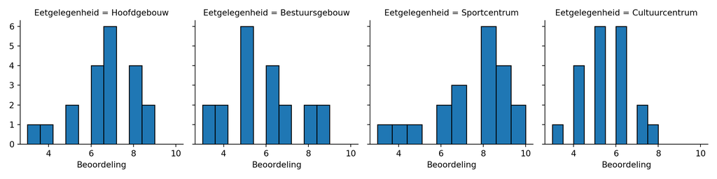

```python
# Laad seaborn of facets te maken
import seaborn as sb
# Laad matplotlib.pyplot om plots te maken
import matplotlib.pyplot as plt

# Maak een facet plot met een histogram voor elke vooropleiding
g = sb.FacetGrid(dfBeoordelingen_eetgelegenheden, col="Eetgelegenheid")
g = (g.map(plt.hist, "Beoordeling", edgecolor = "black").set_axis_labels("Beoordeling"))
plt.show()
```

Bij alle vier de gebouwen lijken er afwijkingen te zijn van de (symmetrische) normale verdeling. De verdeling van het bestuursgebouw heeft een langere staart aan de rechterkant, terwijl de verdelingen van het hoofdgebouw en het sportcentrum juist een langere staart aan de linkerkant hebben. Bij het cultuurcentrum zijn er meer observaties links van het midden dan rechts van het midden, waardoor er ook een vorm van asymmetrie is. Daarom is het een goede optie om *Friedman’s ANOVA* uit te voeren, omdat deze toets niet aan de assumptie van normaliteit hoeft te voldoen.

## 6.3 Friedman’s ANOVA

Voer *Friedman’s ANOVA* uit om de vraag te beantwoorden of er verschillen zijn tussen de (gemiddelde rangnummers van de) beoordelingen van de eetgelegenheden in de vier gebouwen op de campus van de hogeschool. Gebruik de functie `friedmanchisquare()` van het package `scipy` met als argumenten de vier variabelen met de beoordelingen voor elk van de vier gebouwen. Bij deze functie toetst Python standaard tweezijdig.

```python
import numpy as np

# Maak een variabele met het aantal studiepunten voor elke vooropleiding
dfHG = np.array(dfBeoordelingen_eetgelegenheden[dfBeoordelingen_eetgelegenheden['Eetgelegenheid'] == "Hoofdgebouw"]['Beoordeling'])
dfBG = np.array(dfBeoordelingen_eetgelegenheden[dfBeoordelingen_eetgelegenheden['Eetgelegenheid'] == "Bestuursgebouw"]['Beoordeling'])
dfSC = np.array(dfBeoordelingen_eetgelegenheden[dfBeoordelingen_eetgelegenheden['Eetgelegenheid'] == "Sportcentrum"]['Beoordeling'])
dfCC = np.array(dfBeoordelingen_eetgelegenheden[dfBeoordelingen_eetgelegenheden['Eetgelegenheid'] == "Cultuurcentrum"]['Beoordeling'])

# Voer de Kruskal Wallis toets uit
import scipy.stats as sp
print(sp.friedmanchisquare(dfHG, dfBG, dfSC, dfCC))
```

```
## FriedmanchisquareResult(statistic=12.367021276595745, pvalue=0.006226044431771757)
```

Bereken vervolgens de effectmaat *Kendall’s W* op basis van de *χ<sup>2</sup>* waarde van *Friedman’s ANOVA*.

```python
# Sla de Chi-kwadraat waarde op
Chi2, pval = sp.friedmanchisquare(dfHG, dfBG, dfSC, dfCC)

# Sla het aantal observatie-eenheden op
N = len(dfBeoordelingen_eetgelegenheden['Studentnummer'].unique())

# Sla het aantal groepen op
k = len(dfBeoordelingen_eetgelegenheden['Eetgelegenheid'].unique())


# Bereken de effectmaat
W = Chi2 / (N * (k - 1))

# Print de effectmaat
print(W)
```

```
## 0.20611702127659576
```

- *χ<sup>2</sup><sub>3</sub>* = 12,37, *p* = 0,006, *W* = 0,21
- De p-waarde is kleiner dan 0,05, dus de H<sub>0</sub> wordt verworpen.[^16]
- Er is een significant verschil tussen de beoordelingen van de eetgelegenheden in de vier gebouwen; het effect van de verschillende gebouwen op de beoordelingen van studenten is klein tot gemiddeld

## 6.4 Post-hoc toets

Voer post-hoc toetsen uit om te onderzoeken tussen welke gebouwen er verschillen zijn in de beoordelingen van studenten. De vier gebouwen zijn het hoofdgebouw, bestuursgebouw, sportcentrum en cultuurcentrum Rembrandt. Gebruik de Wilcoxon signed-rank toets als post-hoc toets met bijbehorende functie `posthoc_wilcoxon()` van het package `scikit_posthocs`. De ingevoerde argumenten van de functie zijn de dataset `dfBeoordelingen_eetgelegenheden`, de afhankelijke variabele `val_col = 'Beoordeling'`, de onafhankelijke variabele `group_col = 'Eetgelegenheid'` en de correctie voor meerdere toetsen `p_adjust = 'bonferroni'`. Het significantieniveau is 0,05.[^17]

```python
import scikit_posthocs as skph

skph.posthoc_wilcoxon(dfBeoordelingen_eetgelegenheden, val_col = 'Beoordeling', group_col = 'Eetgelegenheid', p_adjust = 'bonferroni')
```

```
##                 Hoofdgebouw  Bestuursgebouw  Sportcentrum  Cultuurcentrum
## Hoofdgebouw        1.000000        0.838683      1.000000        0.042711
## Bestuursgebouw     0.838683        1.000000      0.102046        1.000000
## Sportcentrum       1.000000        0.102046      1.000000        0.007256
## Cultuurcentrum     0.042711        1.000000      0.007256        1.000000
##
```

Bereken de effectmaat *r* voor elke individuele post-hoc toets.[^18]

```python
# Sla de p-waarden van de post-hoc toetsen op
pTabel = skph.posthoc_wilcoxon(dfBeoordelingen_eetgelegenheden, val_col = 'Beoordeling', group_col = 'Eetgelegenheid', p_adjust = 'bonferroni')
print(pTabel)
```

```
##                 Hoofdgebouw  Bestuursgebouw  Sportcentrum  Cultuurcentrum
## Hoofdgebouw        1.000000        0.838683      1.000000        0.042711
## Bestuursgebouw     0.838683        1.000000      0.102046        1.000000
## Sportcentrum       1.000000        0.102046      1.000000        0.007256
## Cultuurcentrum     0.042711        1.000000      0.007256        1.000000
```

```python
p_HG_BG = pTabel['Hoofdgebouw']['Bestuursgebouw']
p_HG_SC = pTabel['Hoofdgebouw']['Sportcentrum']
p_HG_CC = pTabel['Hoofdgebouw']['Cultuurcentrum']
p_BG_SC = pTabel['Bestuursgebouw']['Sportcentrum']
p_BG_CC = pTabel['Bestuursgebouw']['Cultuurcentrum']
p_SC_CC = pTabel['Sportcentrum']['Cultuurcentrum']

# Sla het aantal observatie-eenheden op
N = len(dfBeoordelingen_eetgelegenheden['Studentnummer'].unique())

# Bereken de effectgrootte voor een tweezijdige toets
Effectmaat_HG_BG = sp.norm.ppf(p_HG_BG/2) / np.sqrt(N)
Effectmaat_HG_SC = sp.norm.ppf(p_HG_SC/2) / np.sqrt(N)
Effectmaat_HG_CC = sp.norm.ppf(p_HG_CC/2) / np.sqrt(N)
Effectmaat_BG_SC = sp.norm.ppf(p_BG_SC/2) / np.sqrt(N)
Effectmaat_BG_CC = sp.norm.ppf(p_BG_CC/2) / np.sqrt(N)
Effectmaat_SC_CC = sp.norm.ppf(p_SC_CC/2) / np.sqrt(N)
```

De Wilcoxon signed rank toets gebruikt de som van positieve en negatieve rangnummers van de verschilscores om de significantie van de toets te bepalen. Deze sommen beschrijven het verschil tussen twee gepaarde groepen waarbij de groep met een hogere som van rangnummers ook hogere waarden op de afhankelijke variabele heeft. In deze casus heeft het gebouw met hogere rangnummers een hogere beoordeling door studenten. Bereken de som van de positieve en negatieve rangnummers voor alle vergelijkingen.

```python
def Sommen_rangnummers(Gebouw_1, Gebouw_2):
  # Bereken verschilscores
  Verschilscores = np.array(Gebouw_1) - np.array(Gebouw_2)

  # Rangschik de absolute waarden van verschilscores met scipy.rankdata()
  Rangnummers = sp.rankdata(np.abs(Verschilscores))

  # Maak een vector met daarin de tekens (plus of min) van verschilscores) met numpy.sign()
  Tekens = np.sign(Verschilscores)

  # Bereken het aantal en de som van de positieve rangnummers
  N_positief = len(Tekens[Tekens == 1])
  Som_positief = np.sum(Rangnummers[Tekens == 1])

  # Bereken het aantal en de som van de negatieve rangnummers
  N_negatief = len(Tekens[Tekens == -1])
  Som_negatief = np.sum(Rangnummers[Tekens == -1])

  # Print resultaten
  return [N_positief, Som_positief, N_negatief, Som_negatief];

# Definieer variabelen die observaties bevatten voor de verschillende gebouwen
Beoordeling_HG = dfBeoordelingen_eetgelegenheden[dfBeoordelingen_eetgelegenheden['Eetgelegenheid'] == "Hoofdgebouw"]["Beoordeling"]
Beoordeling_BG = dfBeoordelingen_eetgelegenheden[dfBeoordelingen_eetgelegenheden['Eetgelegenheid'] == "Bestuursgebouw"]["Beoordeling"]
Beoordeling_SC = dfBeoordelingen_eetgelegenheden[dfBeoordelingen_eetgelegenheden['Eetgelegenheid'] == "Sportcentrum"]["Beoordeling"]
Beoordeling_CC = dfBeoordelingen_eetgelegenheden[dfBeoordelingen_eetgelegenheden['Eetgelegenheid'] == "Cultuurcentrum"]["Beoordeling"]

# Bereken de gemiddelde rangschikkingen voor elke vergelijking
N_HG_BG_positief, Som_HG_BG_positief, N_HG_BG_negatief, Som_HG_BG_negatief = Sommen_rangnummers(Beoordeling_HG, Beoordeling_BG)

print(N_HG_BG_positief, Som_HG_BG_positief, N_HG_BG_negatief, Som_HG_BG_negatief)
```

```
## 11 140.5 6 63.5
```

```python
N_HG_SC_positief, Som_HG_SC_positief, N_HG_SC_negatief, Som_HG_SC_negatief = Sommen_rangnummers(Beoordeling_HG, Beoordeling_SC)

N_HG_CC_positief, Som_HG_CC_positief, N_HG_CC_negatief, Som_HG_CC_negatief = Sommen_rangnummers(Beoordeling_HG, Beoordeling_CC)

N_BG_SC_positief, Som_BG_SC_positief, N_BG_SC_negatief, Som_BG_SC_negatief = Sommen_rangnummers(Beoordeling_BG, Beoordeling_SC)

N_BG_CC_positief, Som_BG_CC_positief, N_BG_CC_negatief, Som_BG_CC_negatief = Sommen_rangnummers(Beoordeling_BG, Beoordeling_CC)

N_SC_CC_positief, Som_SC_CC_positief, N_SC_CC_negatief, Som_SC_CC_negatief = Sommen_rangnummers(Beoordeling_SC, Beoordeling_CC)
```

[output not shown]

*Tabel 1. Resultaten post-hoc toetsen voor vergelijking hoofdgebouw (HG), bestuursgebouw (BG), sportcentrum (SC) en cultuurcentrum (CC).*

# 7 Rapportage

Post-hoc toetsen met een Bonferroni correctie voor meerdere toetsen zijn uitgevoerd voor alle vergelijkingen tussen twee gebouwen. Hieruit blijkt dat er alleen significante verschillen zijn tussen het hoofdgebouw en cultuurcentrum Rembrandt, en tussen het sportcentrum en cultuurcentrum Rembrandt. De eetgelegenheid van cultuurcentrum Rembrandt wordt slechter beoordeeld dan de eetgelegenheden in het hoofdgebouw en het sportcentrum; verder zijn er geen significante verschillen tussen de beoordelingen van de eetgelegenheden op de campus.

Deze pagina maakt onderdeel uit van het Statistisch Handboek Studiedata, ontwikkeld binnen de zone Veilig en betrouwbaar benutten van studiedata van het Versnellingsplan. R code is uitgevoerd met R versie 4.2.2; Python code is uitgevoerd in Python 3.6.13. De gesimuleerde datasets zijn hier te downloaden.  
© 2023 [Versnellingsplan](https://www.versnellingsplan.nl) - Statistisch Handboek Studiedata - Licentie Laatst gewijzigd op:18-01-2023

[^1]: Bij *Friedman’s ANOVA* en andere nonparametrische toetsen wordt de data eerst gerangschikt zodat elke observatie een rangnummer toegewezen krijgt. Deze rangnummers worden vervolgens gebruikt om de toets uit te voeren.
[^2]: Van Geloven, N. (4 oktober 2019). *Friedman toets*. [Wiki Statistiek Academisch Medisch Centrum](https://wikistatistiek.amc.nl/index.php/Friedman_toets).
[^3]: Universiteit van Amsterdam (7 juli 2014). *Friedmans ANOVA*. [UvA Wiki Methodologiewinkel](https://wiki.uva.nl/methodologiewinkel/index.php/Friedmans_ANOVA).
[^4]: Field, A. (2013). *Discovering statistics using IBM SPSS statistics*. Sage.
[^5]: Een ordinale variabele is een categorische variabele waarbij de categorieën geordend kunnen worden. Een voorbeeld is de variabele beoordeling met de categorieën Onvoldoende, Voldoende, Goed en Uitstekend.
[^6]: Laerd statistics (2018). *Friedman Test in SPSS Statistics*. https://statistics.laerd.com/spss-tutorials/friedman-test-using-spss-statistics.php.
[^7]: Laerd statistics (2018). *Friedman Test in SPSS Statistics*. https://statistics.laerd.com/spss-tutorials/friedman-test-using-spss-statistics.php.
[^8]: Field, A., Miles, J., & Field, Z. (2012). *Discovering statistics using R*. London: Sage publications.
[^9]: University of Sheffield. *Friedman test in SPSS*. [Mathematics and Statistics Help (MASH)](https://www.sheffield.ac.uk/polopoly_fs/1.714575!/file/stcp-marshall-FriedmanS.pdf). Bezocht op 13 maart 2020.
[^10]: *Kendall’s W* wordt berekend door de teststatistiek van *Friedman’s ANOVA* (dit is de *χ<sup>2</sup>*) te delen door het aantal observatie-eenheden *N* en het aantal groepen *k* minus één, i.e. $W = \frac{\chi^2}{N(k-1)}$.
[^11]: Kassambara, A. (2020). *rstatix: Pipe-Friendly Framework for Basic Statistical Tests*. [R package version 0.4.0.](https://CRAN.R-project.org/package=rstatix).
[^12]: University of Sheffield. *Friedman test in SPSS*. [Mathematics and Statistics Help (MASH)](https://www.sheffield.ac.uk/polopoly_fs/1.714575!/file/stcp-marshall-FriedmanS.pdf). Bezocht op 13 maart 2020.
[^13]: Field, A., Miles, J., & Field, Z. (2012). *Discovering statistics using R*. London: Sage publications.
[^14]: De breedte van de staven van het histogram wordt vaak automatisch bepaald, maar kan handmatig aangepast worden. Aangezien de breedte van de staven bepalend zijn voor de indruk die de visualisatie geeft, is het verstandig om hier goed op te letten.
[^15]: De breedte van de staven van het histogram worden hier automatisch bepaald, maar kunnen handmatig aangepast worden. Aangezien de breedte van de staven bepalend zijn voor de indruk die de visualisatie geeft, is het verstandig om hier goed op te letten.
[^16]: In dit voorbeeld wordt uitgegaan van een waarschijnlijkheid van 95% c.q. een p-waardegrens van 0,05. De grens is naar eigen inzicht aan te passen; houd hierbij rekening met type I en type II fouten.
[^17]: In dit voorbeeld wordt uitgegaan van een waarschijnlijkheid van 95% c.q. een p-waardegrens van 0,05. De grens is naar eigen inzicht aan te passen; houd hierbij rekening met type I en type II fouten.
[^18]: De effectmaat *r* wordt voor de Wilcoxon signed rank toets berekend door de *z*-waarde behorend bij de *p*-waarde van de toets te delen door de wortel van het aantal observatie-eenheden, i.e. $\frac{z}{\sqrt{N}}$.